# Estudios de Ciencia de Datos - Semana 01

# 1 Semana 01

## 1.1 Día Lunes

### 1.1.1 Tema 1: Comparación de proporciones y regresión logística

### 1.1.2 Tema 2: Evaluación del modelo logístico

#### 1.1.2.1 Criterios de evaluación

Para estimar la precisión del modelo, se calcularon las siguientes métricas: sensibilidad, especificidad y exactitud, de acuerdo con las siguientes fórmulas:

**Accuracy** = (TP + TN) / (TP + TN + FP + FN)  
**Sensitivity** = TP / (TP + FN)  
**Specificity** = TN / (TN + FP)

#### 1.1.2.2 Ejemplo 1: Diagnóstico de cáncer de mama

```r
# Valores de la matriz de confusión
TP1 <- 40; FN1 <- 10; FP1 <- 5; TN1 <- 45

# Cálculos
accuracy1 <- (TP1 + TN1) / (TP1 + TN1 + FP1 + FN1)
sensitivity1 <- TP1 / (TP1 + FN1)
specificity1 <- TN1 / (TN1 + FP1)

# Mostrar resultados
data.frame(Métrica = c("Exactitud", "Sensibilidad", "Especificidad"),
           Valor = round(c(accuracy1, sensitivity1, specificity1), 2))
```

```
##         Métrica Valor
## 1     Exactitud  0.85
## 2  Sensibilidad  0.80
## 3 Especificidad  0.90
```

#### 1.1.2.3 Ejemplo 2: Predicción de sobrevida

```r
# Valores de la matriz de confusión
TP2 <- 70; FN2 <- 30; FP2 <- 20; TN2 <- 80

# Cálculos
accuracy2 <- (TP2 + TN2) / (TP2 + TN2 + FP2 + FN2)
sensitivity2 <- TP2 / (TP2 + FN2)
specificity2 <- TN2 / (TN2 + FP2)

# Mostrar resultados
data.frame(Métrica = c("Exactitud", "Sensibilidad", "Especificidad"),
           Valor = round(c(accuracy2, sensitivity2, specificity2), 2))
```

```
##         Métrica Valor
## 1     Exactitud  0.75
## 2  Sensibilidad  0.70
## 3 Especificidad  0.80
```

#### 1.1.2.4 Introducción

Estudio del uso de Instagram entre mujeres y hombres con base en proporciones observadas y regresión logística. Este ejemplo se basa en datos simulados inspirados en el libro de estadística.

#### 1.1.2.5 Código en R

```r
library(ggplot2)
```

```r
# Simular los datos
set.seed(123)

n_women <- 1000
n_men <- 1000

p_women <- 0.6108
p_men <- 0.4398

instagram_women <- rbinom(n_women, 1, p_women)
instagram_men <- rbinom(n_men, 1, p_men)

sexo <- c(rep("Mujer", n_women), rep("Hombre", n_men))
instagram <- c(instagram_women, instagram_men)

datos <- data.frame(
  sexo = factor(sexo, levels = c("Hombre", "Mujer")),
  instagram = instagram
)

head(datos)
```

```
##    sexo instagram
## 1 Mujer         1
## 2 Mujer         0
## 3 Mujer         1
## 4 Mujer         0
## 5 Mujer         0
## 6 Mujer         1
```

```r
# Ajustar modelo logístico
modelo <- glm(instagram ~ sexo, data = datos, family = "binomial")
summary(modelo)
```

```
##
## Call:
## glm(formula = instagram ~ sexo, family = "binomial", data = datos)
##
## Coefficients:
##             Estimate Std. Error z value Pr(>|z|)
## (Intercept) -0.27370    0.06384  -4.287 1.81e-05 ***
## sexoMujer    0.72521    0.09101   7.969 1.61e-15 ***
## ---
## Signif. codes:  0 '***' 0.001 '**' 0.01 '*' 0.05 '.' 0.1 ' ' 1
##
## (Dispersion parameter for binomial family taken to be 1)
##
##     Null deviance: 2768.9  on 1999  degrees of freedom
## Residual deviance: 2704.3  on 1998  degrees of freedom
## AIC: 2708.3
##
## Number of Fisher Scoring iterations: 4
```

```r
# Interpretación con odds ratio
exp(coef(modelo))
```

```
## (Intercept)   sexoMujer
##   0.7605634   2.0651719
```

```r
exp(confint(modelo))
```

```
##                2.5 %    97.5 %
## (Intercept) 0.670847 0.8616651
## sexoMujer   1.728557 2.4697039
```

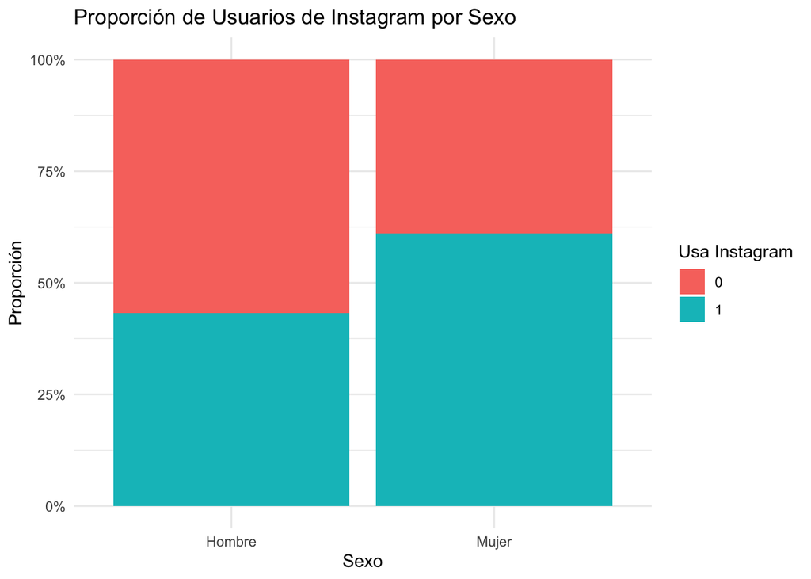

```r
# Visualización de proporciones
ggplot(datos, aes(x = sexo, fill = factor(instagram))) +
  geom_bar(position = "fill") +
  scale_y_continuous(labels = scales::percent) +
  labs(
    title = "Proporción de Usuarios de Instagram por Sexo",
    x = "Sexo",
    y = "Proporción",
    fill = "Usa Instagram"
  ) +
  theme_minimal()
```

#### 1.1.2.6 Resultados esperados

- Mujeres tienen mayor probabilidad (odds ratio > 1) de usar Instagram que los hombres.
- El modelo es significativo si el p-valor del coeficiente asociado a “Mujer” es bajo.
- Visualmente se puede observar esta diferencia en las barras apiladas.

#### Interpretación de la significancia del modelo

Podemos determinar si el modelo es significativo analizando los resultados del resumen de la regresión logística:

```r
summary(modelo)
```

**Extracto del resultado:**

```
Coefficients:
             Estimate Std. Error z value Pr(>|z|)
(Intercept) -0.27370    0.06384  -4.287 1.81e-05 ***
sexoMujer    0.72521    0.09101   7.969 1.61e-15 ***
```

**Interpretación:**

- El valor de `Pr(>|z|)` para el coeficiente `sexoMujer` es **1.61e-15**, lo cual es **mucho menor a 0.05**.
- Esto indica que el predictor `sexo` **es altamente significativo** para predecir el uso de Instagram.
- El símbolo `***` confirma que el efecto es significativo al nivel del 0.1%.

**¿Qué significa esto?**

> Las diferencias entre hombres y mujeres en el uso de Instagram **no son atribuibles al azar**. El modelo encuentra evidencia fuerte para concluir que el sexo tiene un efecto sobre la probabilidad de usar Instagram.

**Prueba formal con anova:**

También podemos realizar una prueba de razón de verosimilitudes:

```r
anova(modelo, test = "Chisq")
```

[output not shown]

Esto nos permitirá verificar si el modelo con `sexo` mejora significativamente respecto al modelo nulo (sin predictores).

#### Intervalo de confianza para los coeficientes logísticos

$$b_1 \pm z^* \cdot SE_{b_1}$$

donde: - $b_1$ es la estimación puntual de la pendiente, - $SE_{b_1}$ es el error estándar de la pendiente, - $z^*$ es el valor crítico de la distribución normal estándar correspondiente al nivel de confianza deseado (por ejemplo, 1.96 para el 95%).

#### Cálculo e interpretación del Odds Ratio y su intervalo de confianza

El **odds ratio** es la razón de las odds para un valor de la variable explicativa igual a $x + 1$, respecto al valor cuando es igual a $x$.

Un **intervalo de confianza de nivel C para el odds ratio** $e^{\beta_1}$ se obtiene transformando el intervalo de confianza del coeficiente de la pendiente $\beta_1$:

$$\left( e^{\beta_1 - z^* \cdot SE_{\beta_1}},\ e^{\beta_1 + z^* \cdot
SE_{\beta_1}} \right)$$

Donde: - $z^*$ es el valor crítico de la distribución normal estándar para el nivel de confianza deseado. - $SE_{\beta_1}$ es el error estándar del coeficiente.

Para probar la hipótesis nula $H_0: \beta_1 = 0$, se calcula el **estadístico de prueba**:

$$z = \frac{\beta_1}{SE_{\beta_1}}$$

El valor $P$ para esta prueba se obtiene evaluando qué tan extremo es este valor de $z$ bajo una distribución normal estándar (cuando $H_0$ es verdadera).

#### Estadístico de Wald y relación con la distribución Chi-cuadrado

A diferencia de otros errores estándar, el cálculo de los errores estándar en regresión logística requiere software estadístico especializado.

El estadístico de prueba $z$ que se usa en regresión logística también se conoce como **estadístico de Wald**. Algunos programas estadísticos reportan el valor de prueba como el cuadrado de este estadístico:

$$X^2 = z^2$$

Este estadístico se llama **estadístico chi-cuadrado**. Cuando la hipótesis nula es verdadera, $X^2$ tiene una distribución $\chi^2$ con 1 grado de libertad. El valor $P$ se calcula como:

$$P(\chi^2 \geq X^2)$$

Dado que el cuadrado de una variable normal estándar sigue una distribución $\chi^2$ con 1 grado de libertad, el estadístico $z$ y el estadístico $\chi^2$ dan los **mismos resultados para inferencia estadística**.

### 1.1.3 Tema 2: *(Reservado para otro artículo)*

*(Aquí se puede agregar un nuevo bloque de análisis siguiendo el mismo formato.)*

### 1.1.4 Tema 3: *(Reservado para otro artículo)*

*(Aquí se puede agregar un nuevo bloque de análisis siguiendo el mismo formato.)*

## 1.2 Día Martes

### 1.2.1 Tema 2: Simulación de respuesta binomial con modelo logístico

#### Introducción

Simulamos 150 observaciones de concentraciones logarítmicas del insecticida para evaluar su efecto sobre la mortalidad de áfidos, utilizando un modelo logístico ajustado a datos reales. Esto permite verificar cómo se comporta el modelo con nuevos datos generados de forma artificial.

#### 1.2.1.1 Código en R

```r
library(ggplot2)
```

```r
# Datos originales
original <- data.frame(
  concentration = c(0.96, 1.33, 1.63, 2.04, 2.32),
  insects_total = c(50, 48, 46, 49, 50),
  insects_killed = c(6, 16, 24, 42, 44)
)
original$insects_alive <- original$insects_total - original$insects_killed

# Modelo base
modelo_base <- glm(cbind(insects_killed, insects_alive) ~ concentration,
                   family = binomial, data = original)

# Simulación de 150 concentraciones
set.seed(42)
sim_conc <- sort(runif(150, min = 0.9, max = 2.4))
predicted_logit <- predict(modelo_base, newdata = data.frame(concentration = sim_conc))
predicted_prob <- exp(predicted_logit) / (1 + exp(predicted_logit))

# Generación de datos simulados
sim_data <- data.frame(
  concentration = sim_conc,
  insects_total = 50,
  prob_killed = predicted_prob
)
sim_data$insects_killed <- rbinom(150, size = sim_data$insects_total, prob = sim_data$prob_killed)
sim_data$insects_alive <- sim_data$insects_total - sim_data$insects_killed

# Modelo sobre datos simulados
modelo_sim <- glm(cbind(insects_killed, insects_alive) ~ concentration,
                  family = binomial, data = sim_data)

# Predicción
sim_data$predicted_prob <- predict(modelo_sim, type = "response")
```

#### 1.2.1.2 Visualización

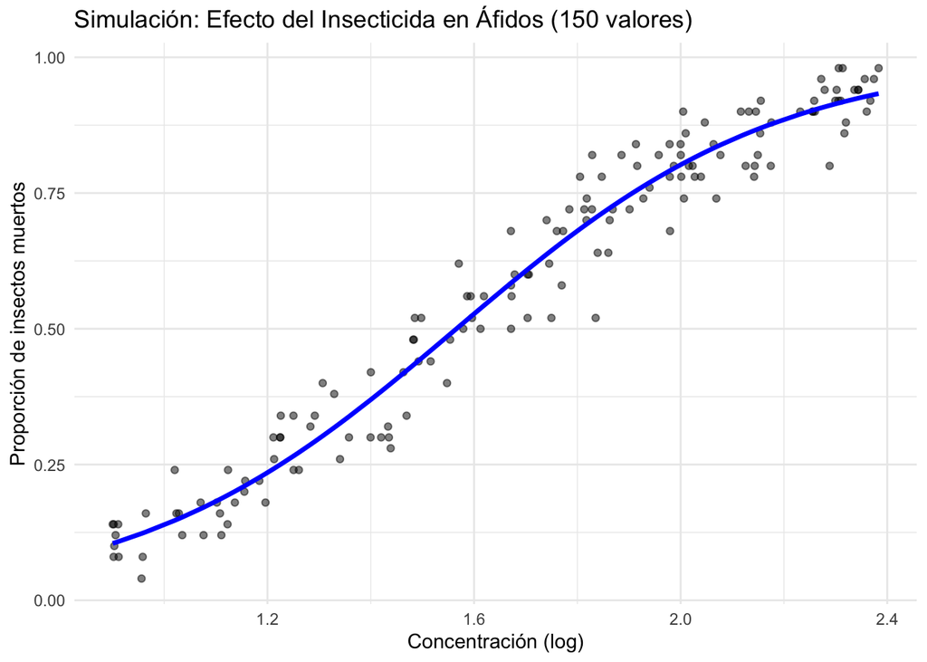

```r
ggplot(sim_data, aes(x = concentration)) +
  geom_point(aes(y = insects_killed / insects_total), alpha = 0.5) +
  geom_line(aes(y = predicted_prob), color = "blue", linewidth = 1.2) +
  labs(title = "Simulación: Efecto del Insecticida en Áfidos (150 valores)",
       x = "Concentración (log)",
       y = "Proporción de insectos muertos") +
  theme_minimal()
```

### Tema 3: Visualización de log-odds y ajuste logístico

#### 1.2.1.3 Figura 1: Log-odds vs concentración (datos originales)

```r
library(dplyr)
```

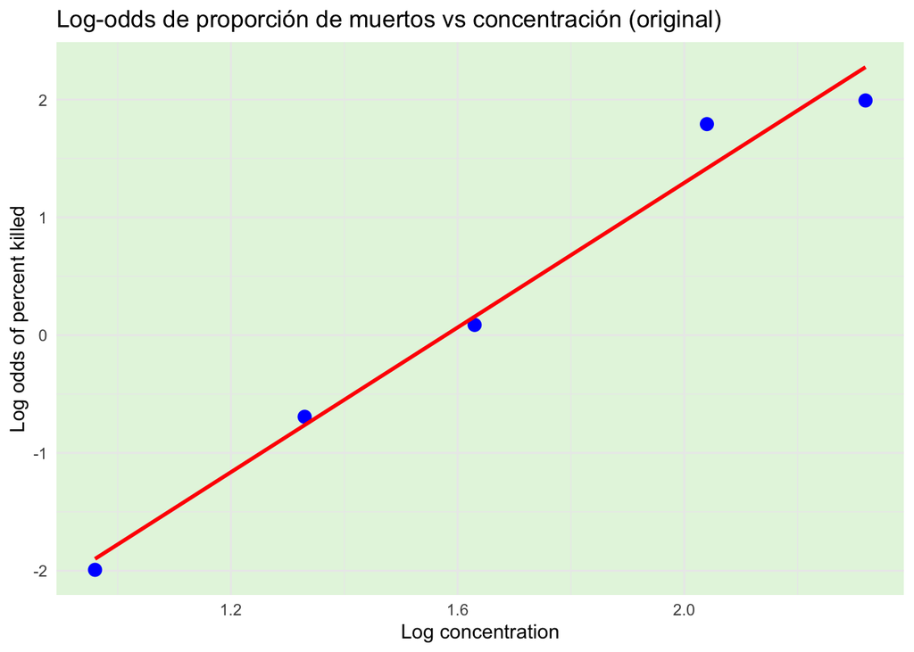

```r
# Preparar datos originales
original <- data.frame(
  concentration = c(0.96, 1.33, 1.63, 2.04, 2.32),
  insects_total = c(50, 48, 46, 49, 50),
  insects_killed = c(6, 16, 24, 42, 44)
)
original <- original %>%
  mutate(prop_killed = insects_killed / insects_total,
         logit_killed = log(prop_killed / (1 - prop_killed)))

# Ajuste lineal sobre logits
modelo_lineal <- lm(logit_killed ~ concentration, data = original)

# Graficar
ggplot(original, aes(x = concentration, y = logit_killed)) +
  geom_point(size = 3, color = "blue") +
  geom_smooth(method = "lm", se = FALSE, color = "red") +
  labs(title = "Log-odds de proporción de muertos vs concentración (original)",
       x = "Log concentration",
       y = "Log odds of percent killed") +
  theme_minimal() +
  theme(panel.background = element_rect(fill = "#e5f5e0", color = NA))
```

#### 1.2.1.4 Figura 2: Ajuste logístico (% muertos vs concentración, datos originales)

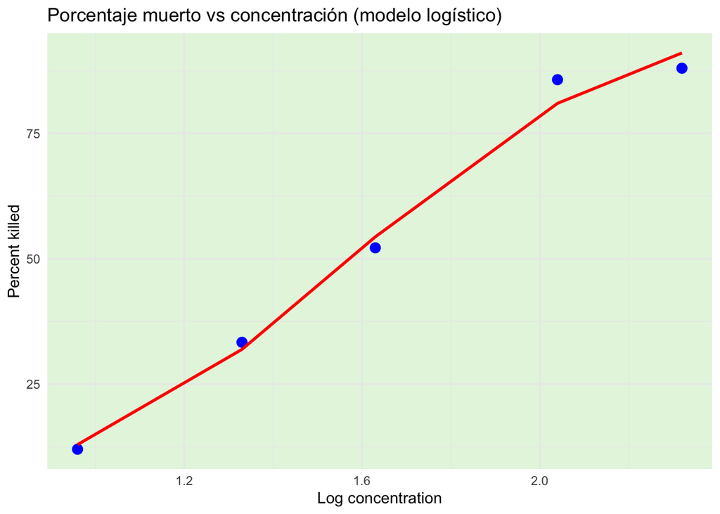

```r
# Ajuste logístico
modelo_logit <- glm(cbind(insects_killed, insects_total - insects_killed) ~ concentration,
                    family = binomial, data = original)

original$predicted_prob <- predict(modelo_logit, type = "response")

ggplot(original, aes(x = concentration)) +
  geom_point(aes(y = prop_killed * 100), size = 3, color = "blue") +
  geom_line(aes(y = predicted_prob * 100), color = "red", size = 1) +
  labs(title = "Porcentaje muerto vs concentración (modelo logístico)",
       x = "Log concentration",
       y = "Percent killed") +
  theme_minimal() +
  theme(panel.background = element_rect(fill = "#e5f5e0", color = NA))
```

#### 1.2.1.5 Figura 3: Log-odds vs concentración (datos simulados)

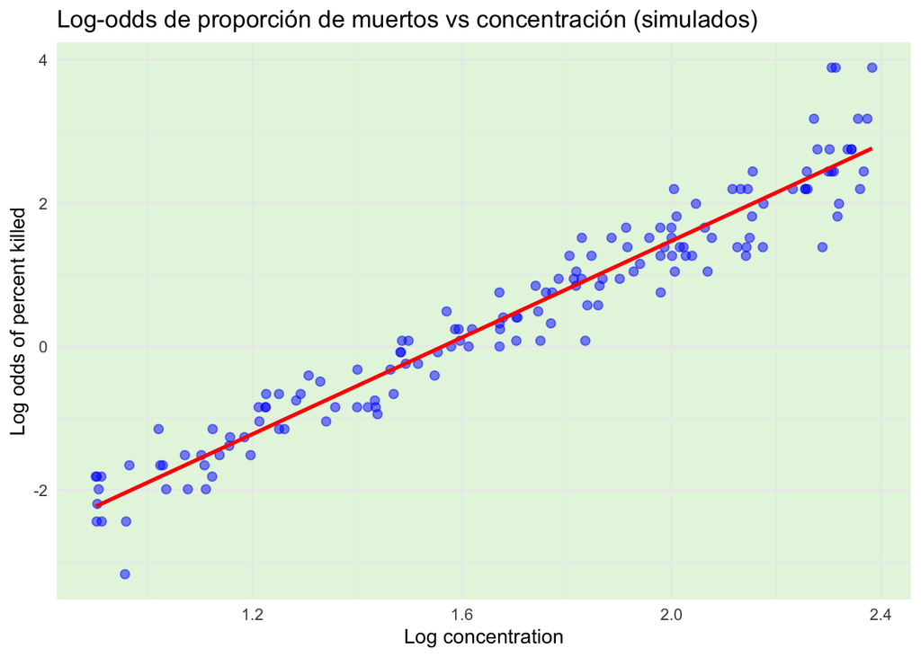

```r
# Preparar datos simulados
sim_data$prop_killed <- sim_data$insects_killed / sim_data$insects_total
sim_data$logit_killed <- log(sim_data$prop_killed / (1 - sim_data$prop_killed))

ggplot(sim_data, aes(x = concentration, y = logit_killed)) +
  geom_point(size = 2, color = "blue", alpha = 0.5) +
  geom_smooth(method = "lm", se = FALSE, color = "red") +
  labs(title = "Log-odds de proporción de muertos vs concentración (simulados)",
       x = "Log concentration",
       y = "Log odds of percent killed") +
  theme_minimal() +
  theme(panel.background = element_rect(fill = "#e5f5e0", color = NA))
```

#### 1.2.1.6 Figura 4: Ajuste logístico (simulados)

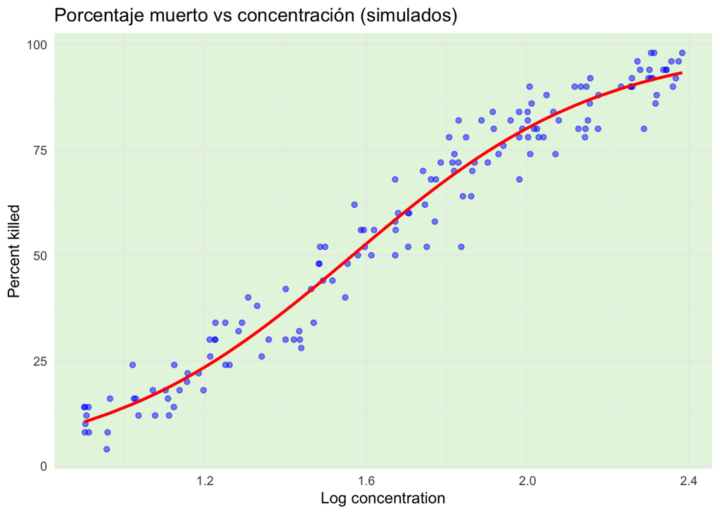

```r
ggplot(sim_data, aes(x = concentration)) +
  geom_point(aes(y = prop_killed * 100), size = 1.5, color = "blue", alpha = 0.5) +
  geom_line(aes(y = predicted_prob * 100), color = "red", size = 1) +
  labs(title = "Porcentaje muerto vs concentración (simulados)",
       x = "Log concentration",
       y = "Percent killed") +
  theme_minimal() +
  theme(panel.background = element_rect(fill = "#e5f5e0", color = NA))
```